# Bayesian Econometrics for Empirical IO -- A journey

## Episode 3: A Berry (1994)-style Discrete Choice model

So far, introducing a Bayesian method sounds rather cosmetic. Instead of assuming a fixed parameter and recovering an estimate and its distribution, we assume a random parameter and recover its posterior distribution. These approaches are philosophically different, but they do not seem to bring much more than a robustness test so far. Before moving on to more advanced models in which the Bayesian approach may yield gains, let's write a slightly more advanced discrete choice models with prices, competition and endogeneity.

There are still (J) inside goods, sold by (J) one-product sellers, in each of (M) markets. Each buyer has unit demand and buys at most one good. Prices are endogenous: we simulate equilibrium prices and show how unaddressed endogeneity may lead to bias.

Someone unfamiliar with the IO literature may wonder why we introduce several markets. The reason is that observing how firms compete across different markets gives rise to layers of variation that help identification. Feel free to modify this notebook and try it yourself: a simulation with a single market is usually too fragile to cleanly resolve the endogeneity problem that we discuss below.

The following specification is adopted from Berry (1994). Note that there is still no modelling of random coefficients: \begin{align*} u_{ijm} &= x_{jm}'\theta - \alpha p_{jm} + \xi_{jm} + \varepsilon_{ijm}, \qquad \varepsilon_{ijm} \sim_{\text{iid}} \text{Gumbel}. \end{align*}

Here $\xi_{jm}$ is the unobserved systematic quality of alternative $j$ in market $m$. The econometrician observes $x_{jm}$, $p_{jm}$, and market shares, but not $\xi_{jm}$. Firms, however, observe $\xi_{jm}$ when setting prices.

The implied market shares are: \begin{align*} s_{jm} &= \frac{\exp(x_{jm}'\theta - \alpha p_{jm} + \xi_{jm})}{1+\sum_{k \in \mathcal{J}_m} \exp(x_{km}'\theta - \alpha p_{km} + \xi_{km})},\\ s_{0m} &= \frac{1}{1+\sum_{k \in \mathcal{J}_m} \exp(x_{km}'\theta - \alpha p_{km} + \xi_{km})}. \end{align*}

Therefore, taking the log ratio of product (j)'s share to the outside share gives the Berry inversion: \begin{align*} \log\left(\frac{s_{jm}}{s_{0m}}\right) &= x_{jm}'\theta - \alpha p_{jm} + \xi_{jm}. \end{align*}

This equation looks like a linear regression. The problem is that $p_{jm}$ is endogenous. Products with high unobserved quality $\xi_{jm}$ have higher demand, and firms respond by charging higher prices. Therefore: \begin{align*} \operatorname{Cov}(p_{jm},\xi_{jm}) \neq 0. \end{align*}

As a result, OLS generally gives a biased estimate of the price coefficient.

We assume Bertrand competition. Each firm fixes a price optimally given the best response of all other firms. Firm (j)'s profit in market (m) is: \begin{align*} \pi_{jm}(p_{jm};p_{-jm}) &= (p_{jm} - mc_{jm}) \cdot s_{jm}(p_m). \end{align*}

The first-order condition is: \begin{align*} \frac{\partial}{\partial p_{jm}}\pi_{jm}(p_{jm};p_{-jm}) &= s_{jm}(p_m) + (p_{jm} - mc_{jm})\frac{\partial}{\partial p_{jm}}s_{jm}(p_m) = 0. \end{align*}

Under our logit assumption: \begin{align*} \frac{\partial s_{jm}}{\partial p_{jm}} &= -\alpha s_{jm}(1-s_{jm}). \end{align*}

So the Bertrand first-order condition can be written as: \begin{align*} p_{jm} &= mc_{jm} + \frac{1}{\alpha(1-s_{jm}(p_m))}. \end{align*}

Note the fixed-point nature of the equation above: the price of product (j) depends on its market share, but its market share depends on the full vector of prices. We solve this fixed point numerically in each market.

We model marginal cost linearly: \begin{align*} mc_{jm} &= \gamma_0 + \gamma_w w_{jm} + x_{jm}'\gamma + \omega_{jm}. \end{align*}

Here $w_{jm}$ is an observed cost shifter. It affects marginal cost and therefore equilibrium prices, but it does not enter consumer utility directly. The term $\omega_{jm}$ is an unobserved cost shock.

This structure gives us the IV logic. A valid instrument must shift equilibrium prices, but must be excluded from demand: \begin{align*} \operatorname{Cov}(Z_{jm},p_{jm}) &\neq 0,\\ \operatorname{Cov}(Z_{jm},\xi_{jm}) &= 0. \end{align*}

In the simulation, true marginal cost (mc_{jm}) is available to us because we generated the data. We first use it as an oracle instrument to illustrate the IV logic as clearly as possible. In real data, marginal costs are usually not observed. The realistic analogue is to use observed cost shifters such as (w_{jm}), or BLP-style instruments based on rival product characteristics.

```python
import jax
import jax.numpy as jnp
import blackjax #Bayesian samplers

import math
import numpy as np
import matplotlib.pyplot as plt
import seaborn as sns
import pandas as pd

import statsmodels.formula.api as smf
from linearmodels.iv import IV2SLS

import pyblp
pyblp.options.verbose = False
pyblp.options.digits = 4
```

## Data Simulation

```python
key = jax.random.key(123)

M = 50          # number of markets
J = 15           # products per market
K = 2            # product characteristics

alpha_true = 0.7
theta_true = jnp.array([0.8, 0.6])

# Demand shock strength
xi_scale = 1.5

# Marginal cost parameters
gamma_0 = 0.5
gamma_x = jnp.array([0.05, 0.05])
gamma_w = 0.35
omega_scale = 0.08

# Price iteration
num_price_iter = 500
price_damping = 0.2
```

```python
key_X, key_xi, key_w, key_omega, subkey = jax.random.split(key, 5)

# Observed product characteristics
# Shape: M x J x K
X = jax.random.uniform(key_X, shape=(M, J, K))

# Demand shock: observed by firms, unobserved by econometrician
# Shape: M x J
xi = xi_scale * jax.random.normal(key_xi, shape=(M, J))

# Observed cost shifter: excluded from demand
# Shape: M x J
w = jax.random.uniform(key_w, shape=(M, J))

# Unobserved cost shock
omega = omega_scale * jax.random.normal(key_omega, shape=(M, J))

# Mean utility excluding price and xi
# v_jm = theta_1 x1_jm + theta_2 x2_jm
v = X@theta_true

# Hidden marginal cost
mc = gamma_0 + X@gamma_x + gamma_w * w + omega
```

```python
@jax.jit
def market_shares_one_market(v_m, p_m, xi_m, alpha):
    """
    Inside-good shares in one market.

    v_m:  shape (J,)
    p_m:  shape (J,)
    xi_m: shape (J,)
    """
    delta = v_m - alpha * p_m + xi_m
    full_delta = jnp.concatenate([jnp.array([0.0]), delta])
    full_shares = jax.nn.softmax(full_delta)
    return full_shares[1:]
```

```python
def solve_prices_one_market(
    v_m,
    xi_m,
    mc_m,
    alpha,
    damping=0.7,
    num_iter=500,
):
    """
    Fixed-point algorithm, that solves single-product Bertrand equilibrium prices in one market.
    """
    p0 = mc_m + 1.0 / alpha
    @jax.jit
    def body_fun(_, p):
        s = market_shares_one_market(v_m, p, xi_m, alpha)
        p_target = mc_m + 1.0 / (alpha * (1.0 - s))
        return p + damping * (p_target - p)

    p_eq = jax.lax.fori_loop(0, num_iter, body_fun, p0)
    s_eq = market_shares_one_market(v_m, p_eq, xi_m, alpha)

    return p_eq, s_eq


solve_prices_many_markets = jax.jit(
    jax.vmap(
        solve_prices_one_market,
        in_axes=(0, 0, 0, None, None, None),
    ),
    static_argnames=("num_iter",),
)
```

```python
p_eq, s_eq = solve_prices_many_markets(
    v,
    xi,
    mc,
    alpha_true,
    price_damping,
    num_price_iter,
)
```

```python
#checking that all FOC's are satisfied:
print(jnp.max(jnp.abs(p_eq - (mc + 1/(alpha_true*(1-s_eq))))))
```

```
9.536743e-07
```

```python
#Now, we build a dataset we may see in the real world

market_id = np.repeat(np.arange(M), J)
product_id = np.tile(np.arange(J), M)

agg_data = pd.DataFrame({
    "market_id": market_id,
    "product_id": product_id,

    "market share": np.asarray(s_eq).reshape(-1),
    "prices": np.asarray(p_eq).reshape(-1),

    "x1": np.asarray(X[:, :, 0]).reshape(-1),
    "x2": np.asarray(X[:, :, 1]).reshape(-1),
    "w": np.asarray(w).reshape(-1),

    # Hidden DGP objects, for diagnostics and oracle-IV only
    "xi_true": np.asarray(xi).reshape(-1),
    "mc_true": np.asarray(mc).reshape(-1),
})

# Outside share by market
agg_data["outside share"] = (
    1.0
    - agg_data.groupby("market_id")["market share"].transform("sum")
)

# Berry inversion
agg_data["logratio"] = np.log(
    agg_data["market share"] / agg_data["outside share"]
)

agg_data.head()
```

|  | market_id | product_id | market share | prices | x1 | x2 | w | xi_true | mc_true | outside share | logratio |
| --- | --- | --- | --- | --- | --- | --- | --- | --- | --- | --- | --- |
| 0 | 0 | 0 | 0.004487 | 2.216928 | 0.311737 | 0.171598 | 0.183158 | -1.174208 | 0.781918 | 0.048176 | -2.373708 |
| 1 | 0 | 1 | 0.001273 | 2.267322 | 0.037933 | 0.381706 | 0.862042 | -2.306006 | 0.836930 | 0.048176 | -3.633761 |
| 2 | 0 | 2 | 0.009043 | 2.063396 | 0.519684 | 0.304478 | 0.115692 | -0.826956 | 0.621789 | 0.048176 | -1.672897 |
| 3 | 0 | 3 | 0.017060 | 2.099433 | 0.254136 | 0.439862 | 0.323540 | -0.035779 | 0.646068 | 0.048176 | -1.038155 |
| 4 | 0 | 4 | 0.176472 | 2.349051 | 0.753439 | 0.989069 | 0.270088 | 1.746440 | 0.614354 | 0.048176 | 1.298298 |

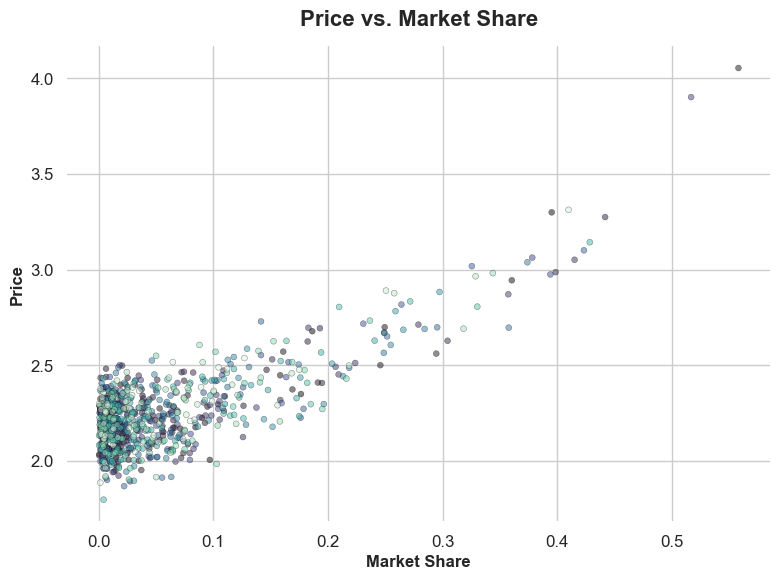

```python
sns.set_theme(style="whitegrid", font_scale=1.1)
plt.figure(figsize=(8, 6))
ax = sns.scatterplot(data=agg_data,
                x='market share',
                y='prices',
                hue='market_id',
                alpha=0.5,
                size=1,
                palette='mako',
                edgecolor='black',
                color='#2077b4',
                legend=None)
plt.title('Price vs. Market Share', fontsize=16, fontweight='bold', pad=15)
plt.ylabel('Price', fontsize=12, fontweight='bold')
plt.xlabel('Market Share', fontsize=12, fontweight='bold')

sns.despine(left=True, bottom=True)

plt.tight_layout()
plt.show()
```

## Warm-up: Frequentist approach

The model above is specified so that it can be estimated with linear models. $v_j$ is an alternative fixed effect, and we treat $\log\left(\frac{s_j}{s_0}\right)$ and prices as data. As is now usual, we do a frequentist warmup, before introducing Bayesian methods. First, we show that OLS yields biased estimates.

```python
ols_model = smf.ols(data=agg_data, formula='logratio ~ 0 + prices + x1 + x2').fit(cov_type='HC1')
print(ols_model.summary()) #see that the coefficients are biased, which should not be a surprise given the price endogeneity
```

```
                                 OLS Regression Results
=======================================================================================
Dep. Variable:               logratio   R-squared (uncentered):                   0.257
Model:                            OLS   Adj. R-squared (uncentered):              0.254
Method:                 Least Squares   F-statistic:                              78.35
Date:                Thu, 07 May 2026   Prob (F-statistic):                    4.51e-44
Time:                        18:06:13   Log-Likelihood:                         -1352.1
No. Observations:                 750   AIC:                                      2710.
Df Residuals:                     747   BIC:                                      2724.
Df Model:                           3
Covariance Type:                  HC1
==============================================================================
                 coef    std err          z      P>|z|      [0.025      0.975]
------------------------------------------------------------------------------
prices        -0.4120      0.067     -6.113      0.000      -0.544      -0.280
x1             0.1998      0.184      1.084      0.278      -0.162       0.561
x2            -0.0469      0.189     -0.249      0.804      -0.417       0.323
==============================================================================
Omnibus:                        1.894   Durbin-Watson:                   2.008
Prob(Omnibus):                  0.388   Jarque-Bera (JB):                1.959
Skew:                          -0.118   Prob(JB):                        0.375
Kurtosis:                       2.916   Cond. No.                         8.74
==============================================================================

Notes:
[1] R² is computed without centering (uncentered) since the model does not contain a constant.
[2] Standard Errors are heteroscedasticity robust (HC1)
```

Two main types of instruments we can use to solve this problem are cost-shifters (here we modeled one as $w$), and BLP instruments, which consist in averaging over rival products' characteristics in each market.

```python
def add_blp_instruments(df, chars=("x1", "x2"), market_col="market_id"):
    df = df.copy()

    for x in chars:
        market_total = df.groupby(market_col)[x].transform("sum")
        df[f"blp_rival_sum_{x}"] = market_total - df[x]

    return df


agg_data = add_blp_instruments(
    agg_data,
    chars=("x1", "x2"),
    market_col="market_id",
)

agg_data.head()
```

|  | market_id | product_id | market share | prices | x1 | x2 | w | xi_true | mc_true | outside share | logratio | blp_rival_sum_x1 | blp_rival_sum_x2 |
| --- | --- | --- | --- | --- | --- | --- | --- | --- | --- | --- | --- | --- | --- |
| 0 | 0 | 0 | 0.004487 | 2.216928 | 0.311737 | 0.171598 | 0.183158 | -1.174208 | 0.781918 | 0.048176 | -2.373708 | 7.915670 | 7.657978 |
| 1 | 0 | 1 | 0.001273 | 2.267322 | 0.037933 | 0.381706 | 0.862042 | -2.306006 | 0.836930 | 0.048176 | -3.633761 | 8.189474 | 7.447869 |
| 2 | 0 | 2 | 0.009043 | 2.063396 | 0.519684 | 0.304478 | 0.115692 | -0.826956 | 0.621789 | 0.048176 | -1.672897 | 7.707722 | 7.525097 |
| 3 | 0 | 3 | 0.017060 | 2.099433 | 0.254136 | 0.439862 | 0.323540 | -0.035779 | 0.646068 | 0.048176 | -1.038155 | 7.973271 | 7.389713 |
| 4 | 0 | 4 | 0.176472 | 2.349051 | 0.753439 | 0.989069 | 0.270088 | 1.746440 | 0.614354 | 0.048176 | 1.298298 | 7.473968 | 6.840506 |

First: see a first-best IV. If we could observe the true marginal cost, it would be an ideal instrument, theoretically grounded in the FOC of the firm's profit maximization problem.

```python
iv_mc_model = IV2SLS.from_formula(
    "logratio ~ 0 + x1 + x2 + [prices ~ mc_true]",
    data=agg_data,
).fit(cov_type="robust")

print(iv_mc_model.summary)
```

```
                          IV-2SLS Estimation Summary
==============================================================================
Dep. Variable:               logratio   R-squared:                      0.2376
Estimator:                    IV-2SLS   Adj. R-squared:                 0.2345
No. Observations:                 750   F-statistic:                    301.89
Date:                Thu, May 07 2026   P-value (F-stat)                0.0000
Time:                        18:06:14   Distribution:                  chi2(3)
Cov. Estimator:                robust

                             Parameter Estimates
==============================================================================
            Parameter  Std. Err.     T-stat    P-value    Lower CI    Upper CI
------------------------------------------------------------------------------
x1             0.7354     0.1941     3.7893     0.0002      0.3550      1.1158
x2             0.5025     0.1941     2.5886     0.0096      0.1220      0.8829
prices        -0.6888     0.0692    -9.9522     0.0000     -0.8244     -0.5531
==============================================================================

Endogenous: prices
Instruments: mc_true
Robust Covariance (Heteroskedastic)
Debiased: False
```

And indeed, the estimates are very close to the true value. But using the marginal cost as an instrument is not realistic: we do not observe it ! At best, we may have access to a cost-shifter like $w$.

```python
iv_w_model = IV2SLS.from_formula(
    "logratio ~ 0 + x1 + x2 + [prices ~ w]",
    data=agg_data,
).fit(cov_type="robust")

print(iv_w_model.summary)
```

```
                          IV-2SLS Estimation Summary
==============================================================================
Dep. Variable:               logratio   R-squared:                      0.2423
Estimator:                    IV-2SLS   Adj. R-squared:                 0.2393
No. Observations:                 750   F-statistic:                    254.15
Date:                Thu, May 07 2026   P-value (F-stat)                0.0000
Time:                        18:06:18   Distribution:                  chi2(3)
Cov. Estimator:                robust

                             Parameter Estimates
==============================================================================
            Parameter  Std. Err.     T-stat    P-value    Lower CI    Upper CI
------------------------------------------------------------------------------
x1             0.6647     0.2440     2.7241     0.0064      0.1865      1.1430
x2             0.4299     0.2352     1.8278     0.0676     -0.0311      0.8910
prices        -0.6522     0.0995    -6.5554     0.0000     -0.8472     -0.4572
==============================================================================

Endogenous: prices
Instruments: w
Robust Covariance (Heteroskedastic)
Debiased: False
```

We get something very close. If we try our BLP instruments:

```python
iv_blp_model = IV2SLS.from_formula(
    "logratio ~ 0 + x1 + x2 + [prices ~ blp_rival_sum_x1 + blp_rival_sum_x2]",
    data=agg_data,
).fit(cov_type="robust")

print(iv_blp_model.summary)
```

```
                          IV-2SLS Estimation Summary
==============================================================================
Dep. Variable:               logratio   R-squared:                      0.2394
Estimator:                    IV-2SLS   Adj. R-squared:                 0.2363
No. Observations:                 750   F-statistic:                    309.42
Date:                Thu, May 07 2026   P-value (F-stat)                0.0000
Time:                        18:06:18   Distribution:                  chi2(3)
Cov. Estimator:                robust

                             Parameter Estimates
==============================================================================
            Parameter  Std. Err.     T-stat    P-value    Lower CI    Upper CI
------------------------------------------------------------------------------
x1             0.7101     0.1938     3.6639     0.0002      0.3303      1.0900
x2             0.4765     0.1983     2.4026     0.0163      0.0878      0.8652
prices        -0.6757     0.0697    -9.6967     0.0000     -0.8123     -0.5391
==============================================================================

Endogenous: prices
Instruments: blp_rival_sum_x1, blp_rival_sum_x2
Robust Covariance (Heteroskedastic)
Debiased: False
```

Also very close. Finally, with all instruments:

```python
iv_all_model = IV2SLS.from_formula(
    """
    logratio ~ 0 + x1 + x2
    + [prices ~ mc_true + w + blp_rival_sum_x1 + blp_rival_sum_x2]
    """,
    data=agg_data,
).fit(cov_type="robust")

print(iv_all_model.summary)
```

```
                          IV-2SLS Estimation Summary
==============================================================================
Dep. Variable:               logratio   R-squared:                      0.2378
Estimator:                    IV-2SLS   Adj. R-squared:                 0.2348
No. Observations:                 750   F-statistic:                    310.46
Date:                Thu, May 07 2026   P-value (F-stat)                0.0000
Time:                        18:06:19   Distribution:                  chi2(3)
Cov. Estimator:                robust

                             Parameter Estimates
==============================================================================
            Parameter  Std. Err.     T-stat    P-value    Lower CI    Upper CI
------------------------------------------------------------------------------
x1             0.7320     0.1909     3.8355     0.0001      0.3579      1.1061
x2             0.4989     0.1939     2.5728     0.0101      0.1188      0.8790
prices        -0.6870     0.0676    -10.165     0.0000     -0.8194     -0.5545
==============================================================================

Endogenous: prices
Instruments: mc_true, w, blp_rival_sum_x1, blp_rival_sum_x2
Robust Covariance (Heteroskedastic)
Debiased: False
```

```python
## Note that we can also use the dedicated package, pyBLP, for this. pyBLP can do the job of computing optimal
## BLP instruments. Since this notebook is dedicated to Bayesian methods, not IO, I just leave it here for reference.
### build the data for pyBLP

product_data = pd.DataFrame({
    "market_ids": agg_data["market_id"].to_numpy(),
    "product_ids": agg_data["product_id"].to_numpy(),

    # Each product is sold by a one-product firm
    "firm_ids": agg_data["product_id"].to_numpy(),

    # Reserved PyBLP names
    "shares": agg_data["market share"].to_numpy(),
    "prices": agg_data["prices"].to_numpy(),

    # Observed demand characteristics
    "x1": agg_data["x1"].to_numpy(),
    "x2": agg_data["x2"].to_numpy(),

    # Excluded demand instruments
    "demand_instruments0": agg_data["w"].to_numpy(),
    "demand_instruments1": agg_data["blp_rival_sum_x1"].to_numpy(),
    "demand_instruments2": agg_data["blp_rival_sum_x2"].to_numpy(),
})
```

```python
formulation = pyblp.Formulation("0 + prices + x1 + x2")

problem_initial = pyblp.Problem(
    product_formulations=formulation,
    product_data=product_data,
)

results_initial = problem_initial.solve()
def extract_beta(results):
    return pd.Series(
        results.beta.flatten(),
        index=["prices", "x1", "x2"],
    )
```

```python
## Final comparison of the frequentist estimates:

truth = pd.Series({
    "prices": -float(alpha_true),
    "x1": float(theta_true[0]),
    "x2": float(theta_true[1]),
})

comparison = pd.DataFrame({
    "True": truth,
    "OLS": ols_model.params[["prices", "x1", "x2"]],
    "IV: oracle mc": iv_mc_model.params[["prices", "x1", "x2"]],
    "IV: w": iv_w_model.params[["prices", "x1", "x2"]],
    "IV: BLP": iv_blp_model.params[["prices", "x1", "x2"]],
    "IV: all": iv_all_model.params[["prices", "x1", "x2"]],
    "PyBLP": extract_beta(results_initial)
})

display(comparison)
```

|  | True | OLS | IV: oracle mc | IV: w | IV: BLP | IV: all | PyBLP |
| --- | --- | --- | --- | --- | --- | --- | --- |
| prices | -0.7 | -0.411961 | -0.688755 | -0.652227 | -0.675682 | -0.686988 | -0.672286 |
| x1 | 0.8 | 0.199829 | 0.735427 | 0.664745 | 0.710131 | 0.732009 | 0.707738 |
| x2 | 0.6 | -0.046943 | 0.502450 | 0.429948 | 0.476503 | 0.498944 | 0.464750 |

## The Bayesian Approach

In Episode 2, we used the Bayesian approach as a substitute for maximum likelihood estimation. In this episode, our parameters $\beta=(\theta_1, \theta_2, \alpha)$ are identified by the moment condition $\text{E}[Z_{jm}\xi_{jm}(\beta)]=0$. One way to introduce a Bayesian approach here is to do Bayesian GMM posterior.

The IV moment condition is: \begin{align*} \mathbb{E}\left[Z_{jm}\xi_{jm}(\beta)\right] &= 0, \end{align*} where \begin{align*} \xi_{jm}(\beta) &= \log\left(\frac{s_{jm}}{s_{0m}}\right) +\alpha p_{jm} - \theta_1x_{1jm} - \theta_2x_{2jm}. \end{align*}

The sample moment is: \begin{align*} g_N(\beta) &= \frac{1}{N}\sum_{m=1}^M\sum_{j=1}^J Z_{jm}\xi_{jm}(\beta). \end{align*}

Classical GMM chooses $\beta$ to minimize: \begin{align*} Q_N(\beta) &= g_N(\beta)'Wg_N(\beta). \end{align*}

The Bayesian GMM approach instead builds a quasi-posterior: \begin{align*} \pi(\beta\mid data) &\propto \exp\left(-\frac{N}{2}Q_N(\beta)\right)\pi(\beta). \end{align*}

This is not a likelihood in the usual parametric sense. It is a likelihood-like object built from the moment restrictions. The posterior concentrates around parameter values that make the IV moments close to zero. To see this, note that, when $Q_N$ is small, $\exp(-N Q_N)$ is large, and the reverse holds as well. This means that the log-posterior "puts" more density on values of the parameters such that the GMM objective is small.

We sample from the posterior distribution above using Bayesian samplers. This procedure is close to the one described in Chernozhukov and Hong (2003) and Yin (2009).

```python
# Outcome
y = jnp.array(agg_data["logratio"].to_numpy())

# Regressors: price, x1, x2
X_gmm = jnp.array(agg_data[["prices", "x1", "x2"]].to_numpy())

# Instruments: exogenous regressors + excluded instruments
Z_gmm = jnp.array(agg_data[["x1", "x2", "w", "blp_rival_sum_x1", "blp_rival_sum_x2"]].to_numpy())

N = y.shape[0]
K_beta = X_gmm.shape[1]
K_z = Z_gmm.shape[1]
```

```python
ZZ = (Z_gmm.T @ Z_gmm) / N
W = jnp.linalg.inv(ZZ + 1e-8 * jnp.eye(K_z)) #GMM weight matrix
```

```python
@jax.jit
def gmm_moments(beta):
    """
    beta = (beta_price, beta_x1, beta_x2)
    """
    xi_beta = y - X_gmm @ beta
    moments = (Z_gmm.T @ xi_beta) / N
    return moments

@jax.jit
def gmm_criterion(beta):
    g = gmm_moments(beta)
    return g @ W @ g

@jax.jit
def log_prior_beta(beta):
    # Weak normal prior
    return -0.5 * jnp.sum((beta / 10.0) ** 2)

@jax.jit
def log_quasi_posterior(beta):
    return -0.5 * N * gmm_criterion(beta) + log_prior_beta(beta)
```

```python
XZ = X_gmm.T @ Z_gmm
ZX = Z_gmm.T @ X_gmm
Zy = Z_gmm.T @ y

beta_gmm_init = jnp.linalg.solve(
    XZ @ W @ ZX,
    XZ @ W @ Zy,
)

print("GMM initialization:", beta_gmm_init)
print("initial quasi posterior:", log_quasi_posterior(beta_gmm_init))
#we initialize the bayesian sampling at the educated guess of the frequentist estimate
```

```
GMM initialization: [-0.6724593   0.7038948   0.47010505]
initial quasi posterior: -0.0965331
```

```python
warmup_key, sample_key, subkey = jax.random.split(subkey, 3)

warmup = blackjax.window_adaptation(
    blackjax.nuts,
    log_quasi_posterior,
    target_acceptance_rate=0.8,
    is_mass_matrix_diagonal=False,
)

adaptation_results, warmup_info = warmup.run(
    warmup_key,
    beta_gmm_init,
    num_steps=1_500,
)

nuts = blackjax.nuts(
    log_quasi_posterior,
    **adaptation_results.parameters,
)
```

```python
def inference_loop(rng_key, kernel, initial_state, num_samples):
    @jax.jit
    def one_step(state, rng_key):
        state, info = kernel(rng_key, state)
        return state, (state.position, info)

    keys = jax.random.split(rng_key, num_samples)
    _, (samples, info) = jax.lax.scan(one_step, initial_state, keys)

    return samples, info


beta_samples, info = inference_loop(
    sample_key,
    nuts.step,
    adaptation_results.state,
    num_samples=25_000,
)

beta_samples.block_until_ready()

print("divergences:", info.is_divergent.sum())
print("mean acceptance rate:", info.acceptance_rate.mean())
```

```
divergences: 0
mean acceptance rate: 0.9076951
```

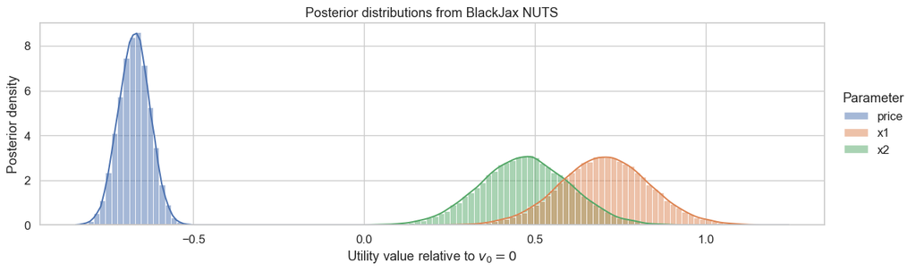

```python
fig, ax = plt.subplots(figsize=(13, 4))
samples_df = pd.DataFrame(beta_samples)
samples_df.columns = ['price', 'x1', 'x2']

sns.histplot(
    data=samples_df,
    bins=120,
    kde=True,
    stat="density",
    common_norm=False,
    fill=True,
    ax=ax,
)

ax.set_title("Posterior distributions from BlackJax NUTS")
ax.set_xlabel(r"Utility value relative to $v_0=0$")
ax.set_ylabel("Posterior density")

sns.move_legend(
    ax,
    "center left",
    bbox_to_anchor=(1.01, 0.5),
    title="Parameter",
    frameon=False,
)

fig.tight_layout()
plt.show()
```

```python
param_names = ["prices", "x1", "x2"]

truth = pd.Series({
    "prices": -float(alpha_true),
    "x1": float(theta_true[0]),
    "x2": float(theta_true[1]),
})

# Bayesian GMM posterior summaries
bayes_mean = pd.Series(np.asarray(beta_samples.mean(axis=0)), index=param_names)

comparison = pd.DataFrame({
    "True": truth,
    "OLS": ols_model.params[param_names],
    "IV: oracle mc": iv_mc_model.params[param_names],
    "IV: w": iv_w_model.params[param_names],
    "IV: BLP": iv_blp_model.params[param_names],
    "IV: all": iv_all_model.params[param_names],
    "PyBLP": extract_beta(results_initial)[param_names],
    "Bayes GMM": bayes_mean,
})

comparison = comparison.round(4)

display(comparison)
```

|  | True | OLS | IV: oracle mc | IV: w | IV: BLP | IV: all | PyBLP | Bayes GMM |
| --- | --- | --- | --- | --- | --- | --- | --- | --- |
| prices | -0.7 | -0.4120 | -0.6888 | -0.6522 | -0.6757 | -0.6870 | -0.6723 | -0.6726 |
| x1 | 0.8 | 0.1998 | 0.7354 | 0.6647 | 0.7101 | 0.7320 | 0.7077 | 0.7039 |
| x2 | 0.6 | -0.0469 | 0.5025 | 0.4299 | 0.4765 | 0.4989 | 0.4648 | 0.4709 |